# Airbnb_Exercise_Student_Facing_170221

### Welcome to the Airbnb Mini Practice Project

Throughout this unit on Python Data Analytics, you'be been introduced the the following powerful libraries:

Matplotlib

Seaborn

Pandas

Each of these libraries will enhance your data analysis capabilities.

We've created this challenging exercise to reinforce your understanding of how these libraries work.

Please note, there is a particular emphasis on the Pandas Library. This is the most critical Python library for data analytics. You'll see many similarities between Pandas and Pivot Tables!

**The most important thing you can do to build confidence with Python is to practice programming, all the time. This way you will build muscle memory. Don't simply copy the code you've written previously. Write it again and again so you store it in your memory.**

**As this is a practice exercise, we've included a copy of what the outputs *should* look like for the majority of the questions to give you some guidance.**

### Time to get started!

Import the airbnb_2.csv file.

Once you do this, you can start your analysis.

**Don't forget to import the libraries you need to read .csv files!**

### Step 1: Import Libraries

**Put your code in the box below.**

```python
import matplotlib.pyplot as plt
import pandas as pd
import seaborn as sns
import numpy as np;
```

### Step 2: Import the Airbnb Dataset

Now that you have the Pandas Libraries imported, it's time to import the Airbnb dataset.

**i) Import the Airbnb dataset.**

ii) Use .info() function to better understand the variables inside your dataset.

**Put your code in the box below**

```python
air=pd.read_csv('airbnb_2.csv');
print(air.head());
print(air.info());
```

```
     id                                              name  host_id  \
0  2539                Clean & quiet apt home by the park     2787
1  2595                             Skylit Midtown Castle     2845
2  3647               THE VILLAGE OF HARLEM....NEW YORK !     4632
3  3831                   Cozy Entire Floor of Brownstone     4869
4  5022  Entire Apt: Spacious Studio/Loft by central park     7192

     host_name neighbourhood_group neighbourhood  latitude  longitude  \
0         John            Brooklyn    Kensington  40.64749  -73.97237
1     Jennifer           Manhattan       Midtown  40.75362  -73.98377
2    Elisabeth           Manhattan        Harlem  40.80902  -73.94190
3  LisaRoxanne            Brooklyn  Clinton Hill  40.68514  -73.95976
4        Laura           Manhattan   East Harlem  40.79851  -73.94399

         room_type  price  minimum_nights  number_of_reviews last_review  \
```

[output cut: 36 more lines]

### Step 3: Exploring your data with Pandas

The rest of these questions will have you focus on using the following Pandas Skills:

Subsetting a Pandas DataFrame using [] and boolean operators

Summing up records with value_counts()

Creating calculated fields

Group By in Pandas

Creating Bar Plots with Matplotlib

**i) Please count how many Airbnb listings are in each of the 5 Neighbourhood Groups (Manhattan, Brooklyn, Queens, Bronx, Staten Island), then identify which Neighbourhood Groups have the greatest number of Airbnb listings.**

**Put your code in the box below**

```python
print(pd.value_counts(air['neighbourhood_group']))
```

```
Manhattan        21661
Brooklyn         20104
Queens            5666
Bronx             1091
Staten Island      373
Name: neighbourhood_group, dtype: int64
```

We want to focus our attention on the 3 most popular Neighbourhood Groups, by listing volume.

**ii) Calculate the percentage of Airbnb listings that each Neighbourhood Group contains.**

See this resource for more details [.](https://pandas.pydata.org/pandas-docs/stable/reference/api/pandas.Series.value_counts.html)

**Put your code in the box below.**

```python
print(pd.value_counts(air['neighbourhood_group'],normalize=True))
```

```
Manhattan        0.443011
Brooklyn         0.411167
Queens           0.115881
Bronx            0.022313
Staten Island    0.007629
Name: neighbourhood_group, dtype: float64
```

**iii) Create a new calculated field called Revenue and place this into the Airbnb DataFrame. This is to be calculated by using the Price Column x Number_Of_Reviews Columns**

**Put your code in the box below**

```python
air['revenue'] = (air['price']* air['number_of_reviews']);
print(air['revenue'].head());
```

```
0     1341
1    10125
2        0
3    24030
4      720
Name: revenue, dtype: int64
```

**iv) Create a Bar Plot that shows which Neighbourhood Group has the highest average revenues. In order to best calculate this, you'd want to consider how you can use the .groupby() syntax to assist you!**

If you're stuck, we recommend you go back to this [DataCamp link](https://learn.datacamp.com/courses/manipulating-dataframes-with-pandas). Specifically, Chapter 4 which covers how GROUP BY is used in Pandas.

**Put your code in the box below.**

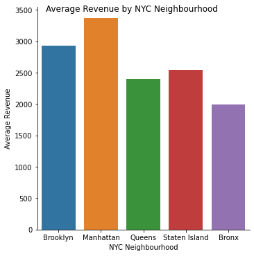

```python
g = sns.catplot(x='neighbourhood_group',y='revenue', kind='bar',data=air,ci=None)
g.fig.suptitle('Average Revenue by NYC Neighbourhood')
g.set(xlabel='NYC Neighbourhood',ylabel='Average Revenue')
plt.show();
```

### Challenge Questions

**V) Filter the Airbnb DataFrame to include only the Neighbourhood Groups Manhattan, Brooklyn, and Queens.**

Then, identify the top 3 Revenue Generating Neighborhoods within each of the 3 Neighbourhood_Groups. This should give us 9 Overall Rows: 3 of the top generating neighbourhoods within each of the 3 Neighbourhood_Groups </b>

This is a tricky question that will *test* your group-by skills.

We recommend you consider the following:

```
condition1 = someDataFrame['someColumn']=='someCondition'
condition2 = someDataFrame['someColumn']=='someCondition'

Step One - Filter the DataFrame using the Conditions
filtered_dataframe = someDataFrame[condition1 OR condition 2]
#Hint: You might want to look up what the OR symbol in Python is represented as in operator form (i.e. AND (&) )

Step Two - Group the Data by Neighbourhood_Group and Neighbourhood. Don't forget you're looking to SUM up the Revenues.

The remaining steps we recommend you think very carefully about.

You might want to make use of the .reset_index(inplace=True) function to help reset the indexes in
your Grouped Up Dataframe...!
```

**Put your code in the box below.**

```python
df = air[(air['neighbourhood_group']=='Manhattan')|(air['neighbourhood_group']=='Brooklyn')|(air['neighbourhood_group']=='Queens')]

sorted_df = df.groupby(['neighbourhood_group','neighbourhood'])['revenue'].sum().sort_values(ascending=False).reset_index()

print(sorted_df);

df1 = sorted_df.sort_values(['neighbourhood_group','revenue'],ascending=False).groupby('neighbourhood_group').head(3)[['neighbourhood_group','neighbourhood','revenue']]

print(df1);
```

```
    neighbourhood_group       neighbourhood   revenue
0              Brooklyn        Williamsburg  12389011
1              Brooklyn  Bedford-Stuyvesant  12352457
2             Manhattan              Harlem   8598692
3             Manhattan      Hell's Kitchen   8238991
4             Manhattan        East Village   7574535
..                  ...                 ...       ...
125              Queens           Bellerose      7762
126            Brooklyn          Mill Basin      7332
127              Queens          Holliswood      2945
128              Queens        Breezy Point       975
129              Queens         Little Neck       872

[130 rows x 3 columns]
   neighbourhood_group       neighbourhood   revenue
17              Queens             Astoria   1880840
28              Queens    Long Island City   1374945
33              Queens            Flushing   1140450
2            Manhattan              Harlem   8598692
3            Manhattan      Hell's Kitchen   8238991
4            Manhattan        East Village   7574535
0             Brooklyn        Williamsburg  12389011
1             Brooklyn  Bedford-Stuyvesant  12352457
8             Brooklyn            Bushwick   4762224
```

**VI) Filter the Airbnb Dataframe to include only the top 3 Neighbroos within each neighbourhood_group.**

After doing this, identify the top average revenue-generating room-type for each of the nine neighbourhoods and plot this in a Bar Chart.</b>

This is a tricky question that will *test* your group-by skills. Think back to the previous question and how you approached this; you can approach this in a similar manner.

We recommend you consider the following:

```
condition1 = someDataFrame['someColumn']=='someCondition'
condition2 = someDataFrame['someColumn']=='someCondition'

Step One - Filter the Dataframe using the Conditions
filtered_dataframe = someDataFrame[condition1 OR condition 2]
#Hint: You might want to look up what the OR symbol in Python is represented as in operator form (i.e. AND (&) )

Step Two - Group the Data by Neighbourhood_Group and Neighbourhood. Don't forget you're looking to SUM up the Revenues.

The remaining steps we recommend you think very carefully about.

You might want to make use of the .reset_index(inplace=True) function to help reset the indexes in
your Grouped Up Dataframe...!
```

**Put your code in the box below.**

```python
sorted_rooms = air.groupby(['room_type','neighbourhood_group','neighbourhood'])['revenue'].mean().sort_values(ascending=False).reset_index()
print(sorted_rooms);

df1 = sorted_rooms.sort_values(['neighbourhood_group','revenue','neighbourhood'],ascending=False).groupby('neighbourhood_group').head(3)[['neighbourhood_group','neighbourhood','room_type','revenue']]
print(df1);

df2 = sorted_rooms.sort_values(['revenue','neighbourhood','neighbourhood_group'],ascending=False).groupby('neighbourhood_group').head(9)[['neighbourhood_group','neighbourhood','room_type','revenue']]
df2['combined']=df2['neighbourhood']+'--'+df2['room_type']
print(df2[['combined','revenue']].head(9));
```

```
           room_type neighbourhood_group      neighbourhood       revenue
0    Entire home/apt              Queens        Bay Terrace  14309.666667
1    Entire home/apt       Staten Island        Silver Lake  11760.000000
2        Shared room           Manhattan  Battery Park City  11275.000000
3        Shared room            Brooklyn       Vinegar Hill   9250.000000
4    Entire home/apt       Staten Island           Huguenot   9026.666667
..               ...                 ...                ...           ...
535  Entire home/apt              Queens          Bellerose      0.000000
536      Shared room              Queens             Hollis      0.000000
537  Entire home/apt       Staten Island            Woodrow      0.000000
538  Entire home/apt       Staten Island     New Dorp Beach      0.000000
539      Shared room           Manhattan    Stuyvesant Town      0.000000

[540 rows x 4 columns]
   neighbourhood_group      neighbourhood        room_type       revenue
```

[output cut: 25 more lines]

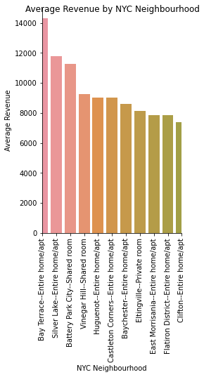

```python
g = sns.catplot(x='combined',y='revenue', kind='bar',data=df2,ci=None)
g.fig.suptitle('Average Revenue by NYC Neighbourhood')
g.set(xlabel='NYC Neighbourhood',ylabel='Average Revenue')
plt.xlim([0, 10])
plt.xticks(rotation=90)
plt.show();
```